# 01.Example 2

Modified

Th 2024-09-05 11:30

## Given:

A long conducting rod of diameter $D$ and electrical resistance per unit length $R'_e$ is initially in thermal equilibrium with the ambient air and its surroundings. This equilibrium is disturbed when an electrical current $I$ is passed through the rod.

Figure 1: Conducting Rod

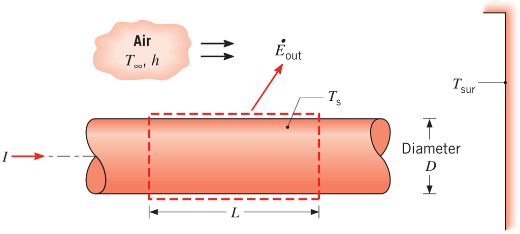

The various parameters are shown below.

$$D = 1\ \mathrm{mm}$$
$$L = 1\ \mathrm{m}$$
$$R'_e = 0.4\ \frac{\mathrm{Ω}}{\mathrm{m}}$$
$$T_\infty = 300\ \mathrm{K}$$
$$T_{sur} = 300\ \mathrm{K}$$
$$h = 100\ \frac{\mathrm{W}}{\left(\mathrm{K} \cdot \mathrm{m}^{2}\right)}$$
$$\varepsilon = 0.8$$

## Required:

Develop an equation that could be used to compute the variation of the rod temperature with current at steady state conditions and fixed environmental conditions. Plot the resulting relationship for current ranging from $0\ \mathrm{A}$ to $10\ \mathrm{A}$.

## Solution:

Equation 1 shows the 1st Law of Thermodynamics

$$\frac{dE_{sys}}{dt} = \Sigma \dot{E}_{in} - \Sigma \dot{E}_{out}
\tag{1}$$

Assuming steady state conditions shows

$$0 = \Sigma \dot{E}_{in} - \Sigma \dot{E}_{out}
\tag{2}$$

The energy entering the system is due to the heat generated by the current. Thus,

$$\Sigma E_{in} = I^2 R'_e L
\tag{3}$$

Recalling that the power of a resistor is

$$P_R = IV = I \left( I R \right) = I^2 R
\tag{4}$$

For this particular rod, the total resistance is given by

$$R = R'_e L
\tag{5}$$

The energy leaving the system is due to the convection and radiation. Thus,

$$\Sigma E_{out} = \dot{Q}_{conv} + \dot{Q}_{rad}
\tag{6}$$

The convection and radiation terms then become

$$\Sigma E_{out} = hA\left( T_s - T_{\infty}\right) + \varepsilon \sigma A \left( T_s^4 - T_{sur}^4\right)
\tag{7}$$

Where the $A$ term is the surface area of the rod and is given by

$$A = \pi D L = 31.4\ \mathrm{cm}^{2}
\tag{8}$$

The simplified energy balance may be found by combining the equations above

$$0 = I^2 R'_e L - h \left( \pi D L\right) \left( T_s - T_{\infty}\right) - \varepsilon \sigma \left( \pi D L\right) \left( T_s^4 - T_{sur}^4\right)
\tag{9}$$

Inspecting the expression above, it may be seen that everything is known expect the surface temperature $T_s$ (while the current $I$ is not a fixed value it is still a known value). Similar to the previous problem, there is no closed-form solution. The Newton-Raphson method of root finding will be implemented again to reach a solution. The `newton_raphson` function is defined below.

```python
def newton_raphson(f, x, xFixed, tol = 0.001):
    h = 0.000000001
    while(abs(f(x, xFixed)) > tol):
        df = (f(x + h, xFixed) - f(x, xFixed))/h
        x = x - f(x, xFixed)/df
    return x
```

The heat transfer expression may now be defined as a python function. This is shown below.

```python
def hx_expr(T_s, I):
    return I**2*R_e*L - h*math.pi*D*L*(T_s - T_inf) - es*sig*math.pi*D*L*(T_s**4 - T_sur**4)
```

```python
intervals = 50
I = [val/intervals for val in range(I_min*intervals, I_max*intervals + 1)]
```

Now for every current value in the range, the surface temperature may be found. This is shown below.

```python
T_s = []
for Ie in I:
    T_s.append(newton_raphson(hx_expr, 100, Ie))
```

The plot may now be generated. This is shown below.

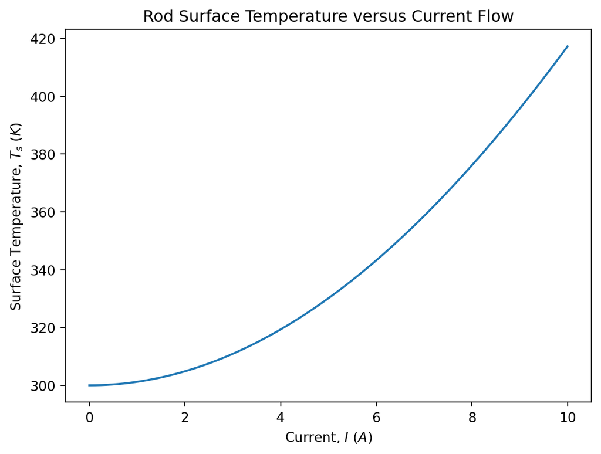

```python
fig, ax = plt.subplots(1, 1)
ax.plot(I, T_s)
ax.set_xlabel('Current, $I\\ \\left(A \\right)$')
ax.set_ylabel('Surface Temperature, $T_s \\ \\left( K \\right)$')
ax.set_title('Rod Surface Temperature versus Current Flow')
plt.show()
```